# Differential Expression Analysis

O. Daniel Lopez Olmos

3/3/2021

# Analisis de expresion diferencial-Introduccion a RNA-seq 2021.

Utilizaremos datos provenientes de un experimento orientado a identificar biomarcadores endocrinos para predecir la progresion de la infeccion por Mycobacterium tuberculosis con el fin de combatir la epidemia en el contexto de contactos domiciliarios. La idea original era visualizar las diferencias entres los grupos control y afectados, pero realizamos un analisis previo y las diferencias de expresion no son tan marcadas, por lo que optamos por realizar el analisis en base a genero.

# Importamos los datos del experimento utilizando ‘recount 3’.

```r
library("recount3")
#seleccionamos nuestro dataset con nombre de proyecto 'SRP098758'
humanProjects <- available_projects()
```

```
## 2021-03-03 21:04:20 caching file sra.recount_project.MD.gz.
```

```
## 2021-03-03 21:04:21 caching file gtex.recount_project.MD.gz.
```

```
## 2021-03-03 21:04:24 caching file tcga.recount_project.MD.gz.
```

```r
projectInfo <- subset(humanProjects, project == "SRP098758" & project_type == "data_sources"
)
```

Creamos el objeto RangedSumarizedExperiment. *Aunque no pudimos transformar las cuentas a CPM, se comentaron las lineas de codigo que podriamos implementar una vez instalada la libreria ‘recount’.*

```r
#library("recount")
#library("edgeR")
#assay(rseProjectTB, "counts") <- getRPKM(rseProjectTB)
#assay(rseProjectTB, "counts") <- cpm(rseProjectTB)

#creamos el objeto RSE
rseProjectTB <- create_rse(projectInfo)
```

```
## 2021-03-03 21:04:32 downloading and reading the metadata.
```

```
## 2021-03-03 21:04:34 caching file sra.sra.SRP098758.MD.gz.
```

```
## 2021-03-03 21:04:36 caching file sra.recount_project.SRP098758.MD.gz.
```

```
## 2021-03-03 21:04:37 caching file sra.recount_qc.SRP098758.MD.gz.
```

```
## 2021-03-03 21:04:39 caching file sra.recount_seq_qc.SRP098758.MD.gz.
```

```
## 2021-03-03 21:04:40 caching file sra.recount_pred.SRP098758.MD.gz.
```

```
## 2021-03-03 21:04:43 downloading and reading the feature information.
```

```
## 2021-03-03 21:04:44 caching file human.gene_sums.G026.gtf.gz.
```

```
## 2021-03-03 21:04:45 downloading and reading the counts: 428 samples across 63856 features.
```

```
## 2021-03-03 21:04:47 caching file sra.gene_sums.SRP098758.G026.gz.
```

```
## 2021-03-03 21:04:56 construcing the RangedSummarizedExperiment (rse) object.
```

```r
#convertimos las cuentas de nivel de nucleotido a nivel de lectura con la funcion
#'compute_read_counts()'
assay(rseProjectTB, "counts") <- compute_read_counts(rseProjectTB)
```

# Exploracion de los datos.

Para investigar si nuestros datos requieren limpeza, exploramos los atributos de las muestras ‘rsa.sample_attributes’.

```r
head(rseProjectTB$sra.sample_attributes)
```

```
## [1] "age;;21|code;;579|gender;;female|group;;case (TB)|site;;MRC|source_name;;Blood|subjectid;;08/G606|tissue;;blood"
## [2] "age;;26|code;;567|gender;;female|group;;case (TB)|site;;MRC|source_name;;Blood|subjectid;;08/G433|tissue;;blood"
## [3] "age;;20|code;;544|gender;;female|group;;Control|site;;MRC|source_name;;Blood|subjectid;;07/G277|tissue;;blood"
## [4] "age;;21|code;;582|gender;;female|group;;Control|site;;MRC|source_name;;Blood|subjectid;;08/G810|tissue;;blood"
## [5] "age;;20|code;;527|gender;;female|group;;Control|site;;MRC|source_name;;Blood|subjectid;;08/G715|tissue;;blood"
## [6] "age;;20|code;;521|gender;;female|group;;Control|site;;MRC|source_name;;Blood|subjectid;;08/G596|tissue;;blood"
```

En el output de la celda anterior se observa que el numero de atributos parace ser el mismo en todas las muestras… Expandemos la informacion de estos atributos.

```r
rseProjectTB <- expand_sra_attributes(rseProjectTB)
```

Para poder utilizar nuestra informacion de la manera correcta, necesitamos contar con los tipos de dato adecuados.

```r
#exploramos de nuevo los atributos para identificar datos que necesiten 'coercion'
colData(rseProjectTB)[
    ,
    grepl("^sra_attribute", colnames(colData(rseProjectTB)))
]
```

```
## DataFrame with 428 rows and 8 columns
##            sra_attribute.age sra_attribute.code sra_attribute.gender
##                  <character>        <character>          <character>
## SRR5225314                21                579               female
## SRR5225315                26                567               female
## SRR5225316                20                544               female
## SRR5225317                21                582               female
## SRR5225318                20                527               female
## ...                      ...                ...                  ...
## SRR5225743                18               1164                 male
## SRR5225744                26               1183                 male
## SRR5225745                NA               1194                   NA
## SRR5225746                23               1196               female
## SRR5225747                18               1198               female
##            sra_attribute.group sra_attribute.site sra_attribute.source_name
##                    <character>        <character>               <character>
## SRR5225314           case (TB)                MRC                     Blood
## SRR5225315           case (TB)                MRC                     Blood
## SRR5225316             Control                MRC                     Blood
## SRR5225317             Control                MRC                     Blood
## SRR5225318             Control                MRC                     Blood
## ...                        ...                ...                       ...
## SRR5225743             Control               AHRI                     Blood
## SRR5225744             Control               AHRI                     Blood
## SRR5225745                  NA                 NA                     Blood
## SRR5225746             Control               AHRI                     Blood
## SRR5225747             Control               AHRI                     Blood
##            sra_attribute.subjectid sra_attribute.tissue
##                        <character>          <character>
## SRR5225314                 08/G606                blood
## SRR5225315                 08/G433                blood
## SRR5225316                 07/G277                blood
## SRR5225317                 08/G810                blood
## SRR5225318                 08/G715                blood
## ...                            ...                  ...
## SRR5225743                W23HHC58                blood
## SRR5225744                 LDHHC10                blood
## SRR5225745                      NA                blood
## SRR5225746                W23HHC78                blood
## SRR5225747                W23HHC03                blood
```

Se observa que algunos atributos necesitan coercion. No podemos clasificar por ‘tissue’ porque todas las muestras provienen de sangre, asi que lo dejamos como caracter.

```r
#transformamos las NAs en ceros para no tener problemas con la coercion
rseProjectTB$sra_attribute.age[is.na(rseProjectTB$sra_attribute.age)] <- 0

#convertimos a los tipos de dato adecuados
rseProjectTB$sra_attribute.age <- as.numeric(rseProjectTB$sra_attribute.age)
rseProjectTB$sra_attribute.gender <- factor(rseProjectTB$sra_attribute.gender, exclude = "NA")
rseProjectTB$sra_attribute.group <- factor(rseProjectTB$sra_attribute.group, exclude = "NA")

#para evitar errores de dimension a la hora de crear el modelo estadistico
#pedimos ignorar ocurrencias de NAs
```

```r
rseProjectTB <- rseProjectTB[,!(is.na(rseProjectTB$sra_attribute.gender))]
rseProjectTB <- rseProjectTB[,!(is.na(rseProjectTB$sra_attribute.group))]
rseProjectTB <- rseProjectTB[,!(is.na(rseProjectTB$sra_attribute.age))]
```

Resumen de las variables que podrian ser de interes

```r
summary(as.data.frame(colData(rseProjectTB)[
    ,
    grepl("^sra_attribute.[age|gender|group|sex]", colnames(colData(rseProjectTB)))
]))
```

```
##  sra_attribute.age sra_attribute.gender sra_attribute.group sra_attribute.site
##  Min.   : 8.00     female:247           case (TB): 99       Length:422
##  1st Qu.:18.00     male  :175           Control  :323       Class :character
##  Median :23.00                                              Mode  :character
##  Mean   :27.77
##  3rd Qu.:35.00
##  Max.   :60.00
##  sra_attribute.source_name sra_attribute.subjectid
##  Length:422                Length:422
##  Class :character          Class :character
##  Mode  :character          Mode  :character
##
##
##
```

# Definiendo las variables a utilizar en el analisis.

La OMS sugiere que las mujeres sufren una mayor afeccion por esta infeccion y que incluso esta afeccion es mayor durante el estadio reproductivo, por lo que resulta interesante investigar las diferencias de expresion entre hombres y mujeres y esperando poder visualizar alguna diferencia entre el grupo de edades en mujeres.

```r
#Definiendo el genero de las muestras como factor
rseProjectTB$Femenino <- factor(ifelse(rseProjectTB$sra_attribute.gender == 'female', "Femenino", "Masculino"), exclude = NA)
table(rseProjectTB$Femenino)
```

```
##
##  Femenino Masculino
##       247       175
```

Utilizamos la informacion que nos provee ‘recount3’ para obtener informacion sobre la calidad de los datos.

```r
#creamos la variable 'asiigned_gene_prop'
#que contiene la proporcion de lecturas asignadas a genes.
rseProjectTB$assigned_gene_prop <- rseProjectTB$recount_qc.gene_fc_count_all.assigned / rseProjectTB$recount_qc.gene_fc_count_all.total

summary(rseProjectTB$assigned_gene_prop)
```

```
##    Min. 1st Qu.  Median    Mean 3rd Qu.    Max.
##  0.2575  0.5082  0.5953  0.5744  0.6567  0.7751
```

Veamos si existen diferencias entre los grupos.

```r
with(colData(rseProjectTB), tapply(assigned_gene_prop, Femenino, summary))
```

```
## $Femenino
##    Min. 1st Qu.  Median    Mean 3rd Qu.    Max.
##  0.2575  0.4978  0.5886  0.5647  0.6449  0.7751
##
## $Masculino
##    Min. 1st Qu.  Median    Mean 3rd Qu.    Max.
##  0.2641  0.5236  0.6017  0.5881  0.6652  0.7450
```

A primera vista, no hay diferencias entre los dos grupos, sin embargo, esta diferencia es mayor a la que obtuvimos con analisis previos, dividiendo las muestras en dos grupos: pacientes sanos(Control) y pacientes afectados(TB). Despues de normalizar los datos, podremos visualizar las diferencias en otra grafica.

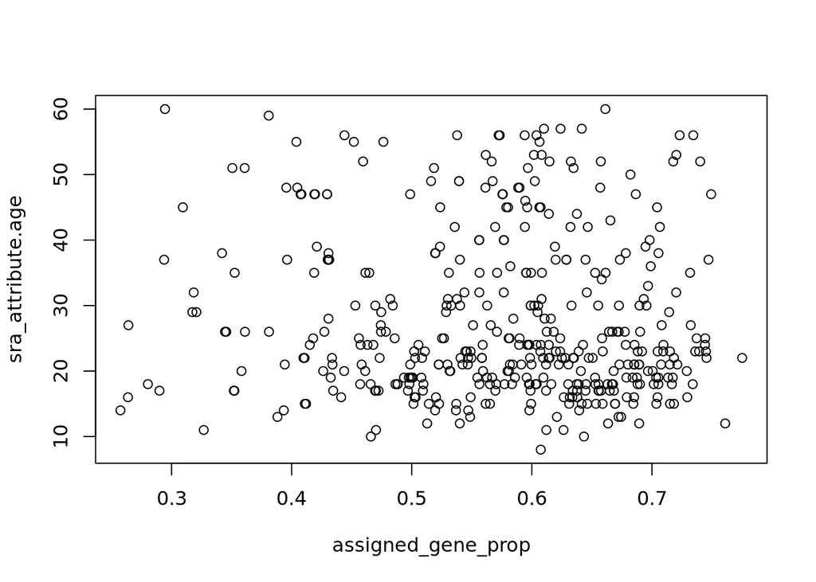

```r
with(colData(rseProjectTB), plot(assigned_gene_prop, sra_attribute.age))
```